# VAR_Model_Cupcakes_v1

Steps for VAR Modeling -

1. Seasonally adjust the data
2. Individual ARIMA models, both time series needs to be I(1) process. Interpret ACF, PACF, Residuals - White noise plots?
3. ADF and KPSS test -> Not stationary.
4. Johanessen test for cointegration.
5. VAR Model - Train / test prediction error

Read seasonally adjusted data for modeling

```r
library(tseries)
library(xlsx)
library(forecast)
setwd("/Users/kevalshah/Keval_Backup/University/UChicago/Capstone/Data/Data Clean up/Clean data to be used for Analysis/Cupcakes")

options(java.parameters = "-Xmx1000m")

cupcakes_data_social <- read.xlsx("Cupcakes_seasonally_adjusted.xlsx", sheetName = "SocialAdj")


# subset the data to have include observations that have both sales and social media data

cupcakes_data_social_ts <- cupcakes_data_social[1:260,]
head(cupcakes_data_social_ts)
```

```
##         Date Twitter...Seasonally.Adjusted Facebook...Seasonally.Adjusted
## 1 2010-01-10                      34975.69                     -717.89224
## 2 2010-01-17                      31292.11                    -2211.20474
## 3 2010-01-24                      13126.95                       94.73516
## 4 2010-01-31                     -21398.08                      -10.76724
## 5 2010-02-07                     -15742.75                     1628.79285
## 6 2010-02-14                    -106007.93                    -1230.11099
##   Blogs...Seasonally.Adjusted Comments...Seasonally.Adjusted
## 1                    6645.111                      -39.74903
## 2                    5952.515                       -4.33076
## 3                    6816.822                      -45.18172
## 4                    7375.750                      -82.09278
## 5                    8918.294                      -88.37403
## 6                    7917.022                     -126.57836
##   Forums...Seasonally.Adjusted Reviews...Seasonally.Adjusted
## 1                    1429.2462                      14.92211
## 2                    1859.8424                      30.24182
## 3                    1490.2270                      33.13124
## 4                    1962.3616                      75.73941
## 5                    2077.7342                      84.65047
## 6                     776.1525                      55.91009
##   Total.Social.Media
## 1          42307.325
## 2          36919.169
## 3          21516.688
## 4         -12077.084
## 5          -3121.649
## 6         -98615.536
```

```r
# Read seasonally adjusted cupcakes sales volume data

cupcakes_data_sales <- read.xlsx("Cupcakes_seasonally_adjusted.xlsx", sheetName = "SalesAdj")


cupcakes_data_sales_ts <- cupcakes_data_sales
head(cupcakes_data_sales_ts)
```

```
##         Date Sales.Seasonally.Adjusted
## 1 2010-01-10                  92.90408
## 2 2010-01-17                  95.91610
## 3 2010-01-24                  74.10600
## 4 2010-01-31                  89.33437
## 5 2010-02-07                  56.99062
## 6 2010-02-14                 149.38485
```

ARIMA Model

```r
# Function
  fun.illustrate.2=function(data,nperiod,p,d,q,P,D,Q) {

    error.holdout = rep(0,nperiod)
    r.sq.error.holdout = rep(0, nperiod)


    for(i in 1:nperiod) {

      # Keeping the first week as hold out for i[1] and then increment until 52nd value
      # 52nd value = 52 week = 1 year i.e last year as hold out.
      cutoff = length(data) - i
      #cutoff = cutoff - i

      #yvec.train=as.vector(data)[1:cutoff]
        if(cutoff >= nperiod) {
        yvec.train=as.vector(data)[1:cutoff]
        #break;
        yvec.hold=as.vector(data)[(cutoff+1):length(data)]
        #yvec.hold

        y=ts(yvec.train, start=2010, frequency=52)
        pred=predict(arima(y, order = c(p,d,q), seasonal = list(order = c(P,D,Q))),n.ahead=(length(data)-cutoff))
        # Predicted - Actual? or Actual - predicted.
        error.holdout[i]=mean((pred$pred-yvec.hold)^2)
        if(length(pred$pred) > 1) {r.sq.error.holdout[i] = (cor(pred$pred,yvec.hold))^2}
        #residuals.holdout[i] = yvec.hold - pred$pred
      }

    }
    # Ignore R Square of the i = 1 when holdout is last week.
    #return(list(error.holdout=error.holdout, Average = (error.holdout)^(1/length(error.holdout))))

    return(list(error.holdout=error.holdout, Average = mean(error.holdout), R.Squared = r.sq.error.holdout, length(pred$pred), length(yvec.hold)))

    #predict(arima(y, order = c(p,d,q), seasonal = list(order = c(P,D,Q))),n.ahead=12)$pred
    #predict(arima(y, order = c(p,d,q), seasonal = list(order = c(P,D,Q))),n.ahead=12)$pred)^2

  }
```

ARIMA for cupcakes Social Media Mentions

```r
# cupcakess Social Media Mentions

f1<- fun.illustrate.2(cupcakes_data_social$Total.Social.Media,52, 2,0,0,0,0,0)
f2<- fun.illustrate.2(cupcakes_data_social$Total.Social.Media,52, 2,0,1,0,0,0)
f3<- fun.illustrate.2(cupcakes_data_social$Total.Social.Media,52, 2,0,2,0,0,0)
f4<- fun.illustrate.2(cupcakes_data_social$Total.Social.Media,52, 2,1,1,0,0,0)
f5<- fun.illustrate.2(cupcakes_data_social$Total.Social.Media,52, 2,1,2,0,0,0)
f6<- fun.illustrate.2(cupcakes_data_social$Total.Social.Media,52, 2,1,0,0,0,0)
f7<- fun.illustrate.2(cupcakes_data_social$Total.Social.Media,52, 2,2,0,0,0,0)
f8<- fun.illustrate.2(cupcakes_data_social$Total.Social.Media,52, 2,2,1,0,0,0)
f9<- fun.illustrate.2(cupcakes_data_social$Total.Social.Media,52, 2,2,2,0,0,0)

f10<-fun.illustrate.2(cupcakes_data_social$Total.Social.Media,52, 1,0,0,0,0,0)
f11<-fun.illustrate.2(cupcakes_data_social$Total.Social.Media,52, 1,0,1,0,0,0)
f12<-fun.illustrate.2(cupcakes_data_social$Total.Social.Media,52, 1,0,2,0,0,0)
f13<-fun.illustrate.2(cupcakes_data_social$Total.Social.Media,52, 1,1,1,0,0,0)
f14<-fun.illustrate.2(cupcakes_data_social$Total.Social.Media,52, 1,1,2,0,0,0)
f15<-fun.illustrate.2(cupcakes_data_social$Total.Social.Media,52, 1,1,0,0,0,0)
f16<-fun.illustrate.2(cupcakes_data_social$Total.Social.Media,52, 1,2,0,0,0,0)
f17<-fun.illustrate.2(cupcakes_data_social$Total.Social.Media,52, 1,2,1,0,0,0)
f18<-fun.illustrate.2(cupcakes_data_social$Total.Social.Media,52, 1,2,2,0,0,0)

f19<-fun.illustrate.2(cupcakes_data_social$Total.Social.Media,52, 0,0,0,0,0,0)
f20<-fun.illustrate.2(cupcakes_data_social$Total.Social.Media,52, 0,0,1,0,0,0)
f21<-fun.illustrate.2(cupcakes_data_social$Total.Social.Media,52, 0,0,2,0,0,0)
f22<-fun.illustrate.2(cupcakes_data_social$Total.Social.Media,52, 0,1,0,0,0,0)
f23<-fun.illustrate.2(cupcakes_data_social$Total.Social.Media,52, 0,1,1,0,0,0)
f24<-fun.illustrate.2(cupcakes_data_social$Total.Social.Media,52, 0,1,2,0,0,0)
f25<-fun.illustrate.2(cupcakes_data_social$Total.Social.Media,52, 0,2,0,0,0,0)
f26<-fun.illustrate.2(cupcakes_data_social$Total.Social.Media,52, 0,2,1,0,0,0)
f27<-fun.illustrate.2(cupcakes_data_social$Total.Social.Media,52, 0,2,2,0,0,0)

# Concatenate
total.social_media <- c(f1$Average, f2$Average, f3$Average, f4$Average, f5$Average, f6$Average, f7$Average, f8$Average,f9$Average, f10$Average, f11$Average, f12$Average, f13$Average, f14$Average, f15$Average, f16$Average, f17$Average, f18$Average, f19$Average, f20$Average, f21$Average, f22$Average, f23$Average, f24$Average, f25$Average, f26$Average, f27$Average)

# Minimum
summary(total.social_media)
```

```
##      Min.   1st Qu.    Median      Mean   3rd Qu.      Max.
## 9.020e+08 9.177e+08 1.033e+09 1.035e+10 1.930e+09 1.749e+11
```

```r
which.min(total.social_media)
```

```
## [1] 1
```

```r
# Auto ARIMA (3,1,2)
auto.total.social.media <- auto.arima(cupcakes_data_social$Total.Social.Media)
auto.total.social.media
```

```
## Series: cupcakes_data_social$Total.Social.Media
## ARIMA(3,1,2) with drift
##
## Coefficients:
##          ar1      ar2      ar3      ma1     ma2     drift
##       0.9056  -0.0375  -0.1653  -1.6262  0.7288  759.2859
## s.e.  0.2370   0.0887   0.0905   0.2339  0.1580  517.7767
##
## sigma^2 estimated as 576172751:  log likelihood=-2968.19
## AIC=5950.38   AICc=5950.83   BIC=5975.28
```

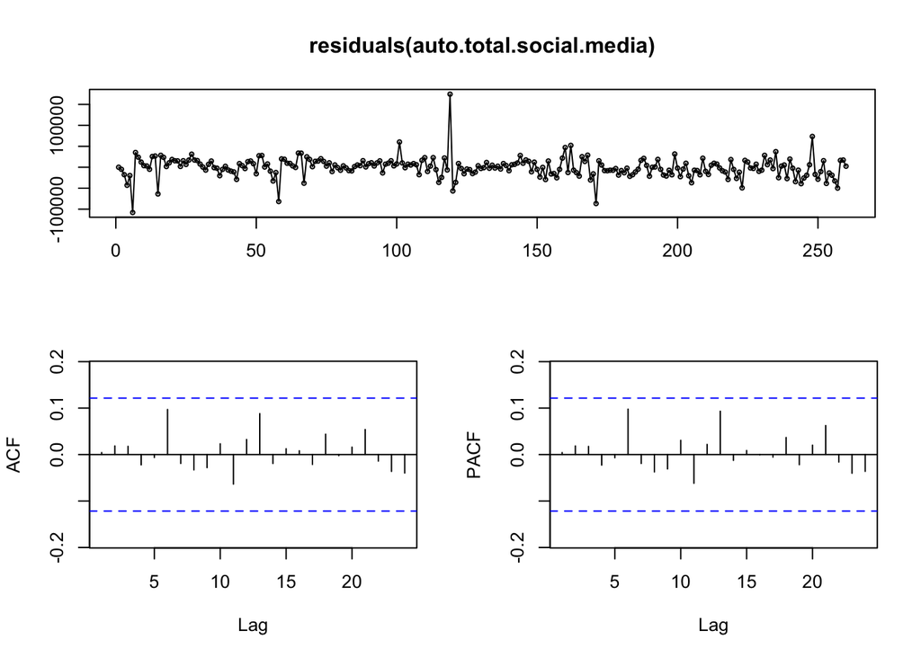

```r
tsdisplay(residuals(auto.total.social.media))
```

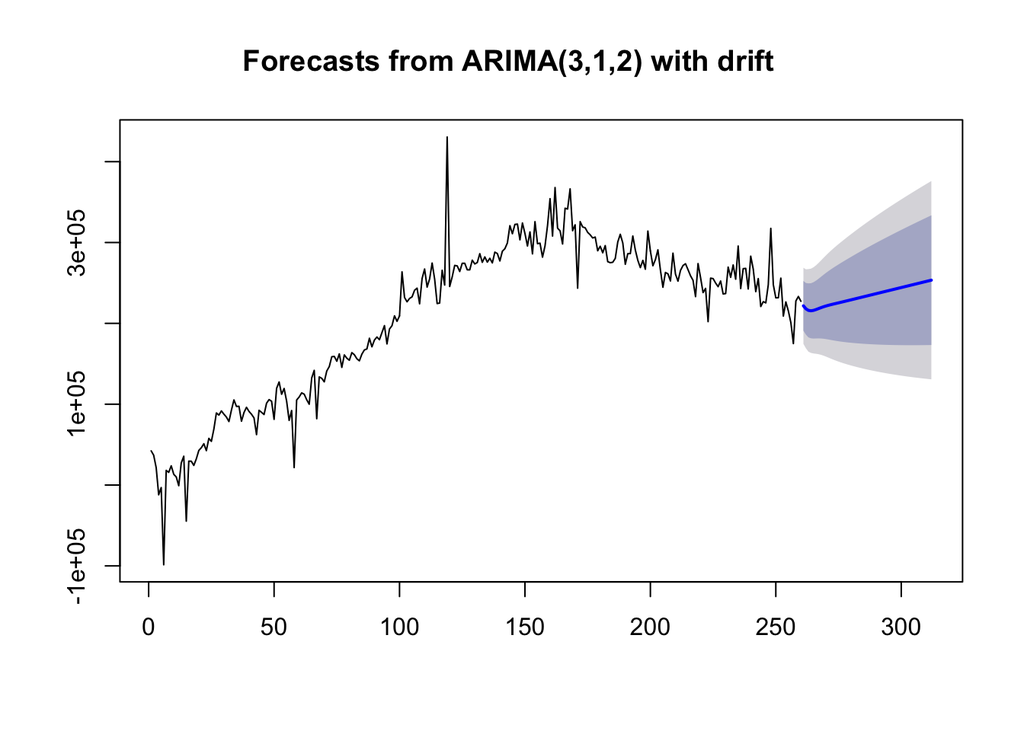

```r
# Forecast Auto ARIMA
auto.total.social.media.forecast <- forecast(auto.total.social.media, h=52)
plot(auto.total.social.media.forecast)
```

```r
# Train and Test Split
cupcakes_train_social_data_arima <- cupcakes_data_social_ts[1:208,8]
head(cupcakes_train_social_data_arima)
```

```
## [1]  42307.325  36919.169  21516.688 -12077.084  -3121.649 -98615.536
```

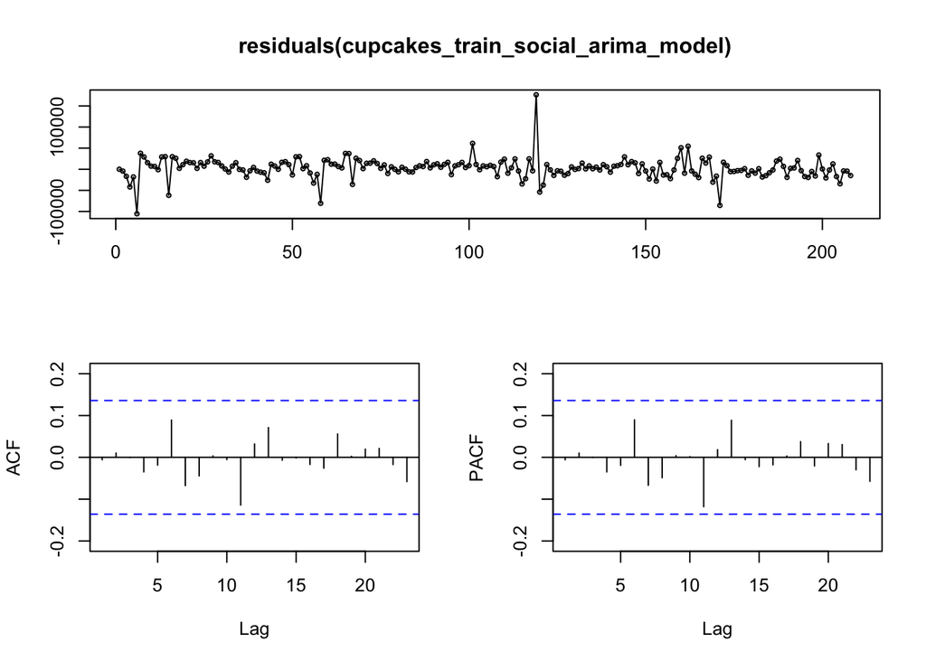

```r
# Choosing Auto.arima - ARIMA(3,1,2,0,0,0)
cupcakes_train_social_arima_model <- Arima(cupcakes_train_social_data_arima, order=c(3,1,2))
tsdisplay(residuals(cupcakes_train_social_arima_model))
```

```r
# Forecasting
forecast.cupcakes.social.arima <- forecast(cupcakes_train_social_arima_model, h=52)
forecast.cupcakes.social.arima$mean
```

```
## Time Series:
## Start = 209
## End = 260
## Frequency = 1
##  [1] 262131.1 260320.5 259988.0 257882.7 256263.6 254876.9 254030.9
##  [8] 253591.8 253472.5 253536.6 253684.6 253844.1 253976.8 254067.7
## [15] 254118.2 254137.3 254136.2 254124.9 254110.6 254097.8 254088.5
## [22] 254082.8 254080.3 254079.8 254080.6 254081.8 254083.0 254084.0
## [29] 254084.6 254084.9 254085.0 254085.0 254084.9 254084.8 254084.7
## [36] 254084.6 254084.6 254084.5 254084.5 254084.6 254084.6 254084.6
## [43] 254084.6 254084.6 254084.6 254084.6 254084.6 254084.6 254084.6
## [50] 254084.6 254084.6 254084.6
```

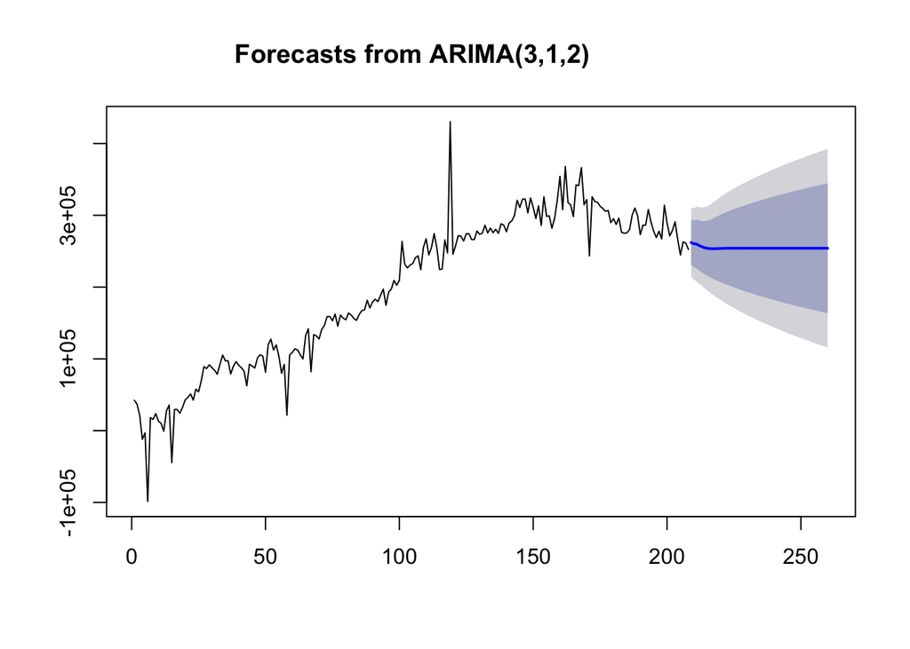

```r
# Plot
plot(forecast(object=forecast.cupcakes.social.arima,h="52"))
```

Residuals look like white noise. The total social media mentions are of I(1), therefore the series is integrated.

ARIMA for cupcakes Sales Volume

```r
# cupcakess Sales Volume

f1<- fun.illustrate.2(cupcakes_data_sales_ts$Sales.Seasonally.Adjusted,52, 2,0,0,0,0,0)
f2<- fun.illustrate.2(cupcakes_data_sales_ts$Sales.Seasonally.Adjusted,52, 2,0,1,0,0,0)
f3<- fun.illustrate.2(cupcakes_data_sales_ts$Sales.Seasonally.Adjusted,52, 2,0,2,0,0,0)
f4<- fun.illustrate.2(cupcakes_data_sales_ts$Sales.Seasonally.Adjusted,52, 2,1,1,0,0,0)
f5<- fun.illustrate.2(cupcakes_data_sales_ts$Sales.Seasonally.Adjusted,52, 2,1,2,0,0,0)
f6<- fun.illustrate.2(cupcakes_data_sales_ts$Sales.Seasonally.Adjusted,52, 2,1,0,0,0,0)
f7<- fun.illustrate.2(cupcakes_data_sales_ts$Sales.Seasonally.Adjusted,52, 2,2,0,0,0,0)
f8<- fun.illustrate.2(cupcakes_data_sales_ts$Sales.Seasonally.Adjusted,52, 2,2,1,0,0,0)
f9<- fun.illustrate.2(cupcakes_data_sales_ts$Sales.Seasonally.Adjusted,52, 2,2,2,0,0,0)

f10<-fun.illustrate.2(cupcakes_data_sales_ts$Sales.Seasonally.Adjusted,52, 1,0,0,0,0,0)
f11<-fun.illustrate.2(cupcakes_data_sales_ts$Sales.Seasonally.Adjusted,52, 1,0,1,0,0,0)
f12<-fun.illustrate.2(cupcakes_data_sales_ts$Sales.Seasonally.Adjusted,52, 1,0,2,0,0,0)
f13<-fun.illustrate.2(cupcakes_data_sales_ts$Sales.Seasonally.Adjusted,52, 1,1,1,0,0,0)
f14<-fun.illustrate.2(cupcakes_data_sales_ts$Sales.Seasonally.Adjusted,52, 1,1,2,0,0,0)
f15<-fun.illustrate.2(cupcakes_data_sales_ts$Sales.Seasonally.Adjusted,52, 1,1,0,0,0,0)
f16<-fun.illustrate.2(cupcakes_data_sales_ts$Sales.Seasonally.Adjusted,52, 1,2,0,0,0,0)
f17<-fun.illustrate.2(cupcakes_data_sales_ts$Sales.Seasonally.Adjusted,52, 1,2,1,0,0,0)
f18<-fun.illustrate.2(cupcakes_data_sales_ts$Sales.Seasonally.Adjusted,52, 1,2,2,0,0,0)

f19<-fun.illustrate.2(cupcakes_data_sales_ts$Sales.Seasonally.Adjusted,52, 0,0,0,0,0,0)
f20<-fun.illustrate.2(cupcakes_data_sales_ts$Sales.Seasonally.Adjusted,52, 0,0,1,0,0,0)
f21<-fun.illustrate.2(cupcakes_data_sales_ts$Sales.Seasonally.Adjusted,52, 0,0,2,0,0,0)
f22<-fun.illustrate.2(cupcakes_data_sales_ts$Sales.Seasonally.Adjusted,52, 0,1,0,0,0,0)
f23<-fun.illustrate.2(cupcakes_data_sales_ts$Sales.Seasonally.Adjusted,52, 0,1,1,0,0,0)
f24<-fun.illustrate.2(cupcakes_data_sales_ts$Sales.Seasonally.Adjusted,52, 0,1,2,0,0,0)
f25<-fun.illustrate.2(cupcakes_data_sales_ts$Sales.Seasonally.Adjusted,52, 0,2,0,0,0,0)
f26<-fun.illustrate.2(cupcakes_data_sales_ts$Sales.Seasonally.Adjusted,52, 0,2,1,0,0,0)
f27<-fun.illustrate.2(cupcakes_data_sales_ts$Sales.Seasonally.Adjusted,52, 0,2,2,0,0,0)

# Concatenate
total.sales.volume <- c(f1$Average, f2$Average, f3$Average, f4$Average, f5$Average, f6$Average, f7$Average, f8$Average,f9$Average, f10$Average, f11$Average, f12$Average, f13$Average, f14$Average, f15$Average, f16$Average, f17$Average, f18$Average, f19$Average, f20$Average, f21$Average, f22$Average, f23$Average, f24$Average, f25$Average, f26$Average, f27$Average)

# Minimum
summary(total.sales.volume)
```

```
##    Min. 1st Qu.  Median    Mean 3rd Qu.    Max.
##    1933    2070    2565   46780    4498  703400
```

```r
which.min(total.sales.volume)
```

```
## [1] 5
```

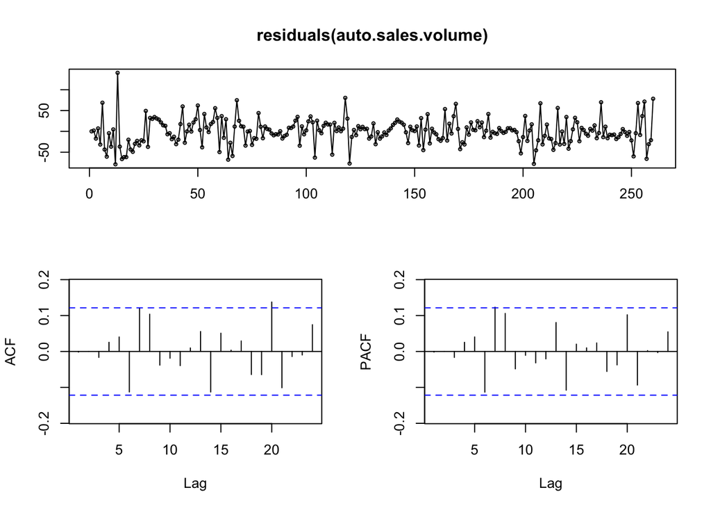

```r
# Auto ARIMA (2,1,2)
auto.sales.volume <- auto.arima(cupcakes_data_sales_ts$Sales.Seasonally.Adjusted)
tsdisplay(residuals(auto.sales.volume))
```

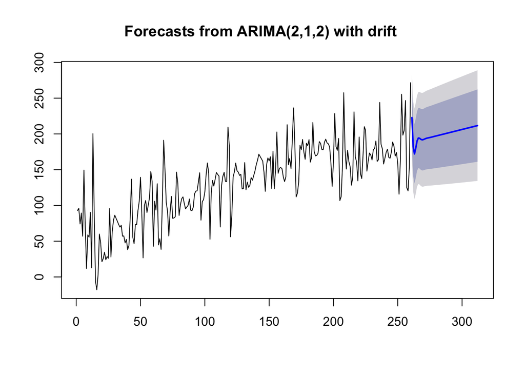

```r
# Forecast Auto ARIMA
auto.sales.volume.forecast <- forecast(auto.sales.volume, h=52)
plot(auto.sales.volume.forecast)
```

```r
# Train and Test Split
cupcakes_train_sales_data_arima <- cupcakes_data_sales_ts[1:208,2]
head(cupcakes_train_sales_data_arima)
```

```
## [1]  92.90408  95.91610  74.10600  89.33437  56.99062 149.38485
```

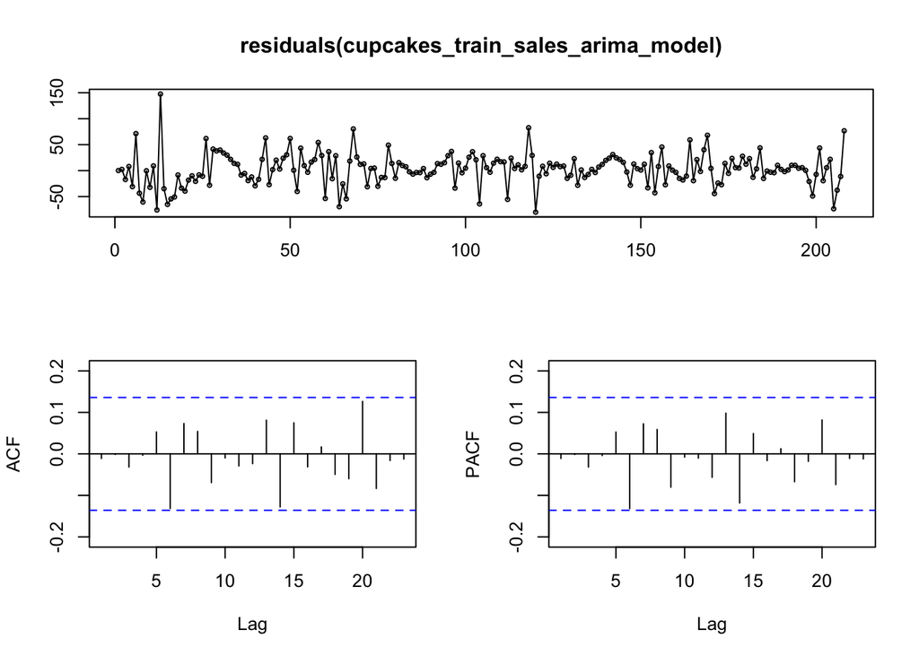

```r
# Choosing Model 17 - ARIMA(2,1,2,0,0,0)
cupcakes_train_sales_arima_model <- Arima(cupcakes_train_sales_data_arima, order=c(2,1,2))
tsdisplay(residuals(cupcakes_train_sales_arima_model))
```

```r
# Forecasting
forecast.cupcakes.sales.arima <- forecast(cupcakes_train_sales_arima_model, h=52)
forecast.cupcakes.sales.arima$mean
```

```
## Time Series:
## Start = 209
## End = 260
## Frequency = 1
##  [1] 206.2756 166.8020 155.5121 161.8652 171.2481 176.1993 176.4797
##  [8] 174.7860 173.3403 172.8539 173.0290 173.3554 173.5453 173.5691
## [15] 173.5144 173.4620 173.4418 173.4461 173.4573 173.4645 173.4659
## [22] 173.4641 173.4623 173.4614 173.4615 173.4619 173.4622 173.4622
## [29] 173.4622 173.4621 173.4621 173.4621 173.4621 173.4621 173.4621
## [36] 173.4621 173.4621 173.4621 173.4621 173.4621 173.4621 173.4621
## [43] 173.4621 173.4621 173.4621 173.4621 173.4621 173.4621 173.4621
## [50] 173.4621 173.4621 173.4621
```

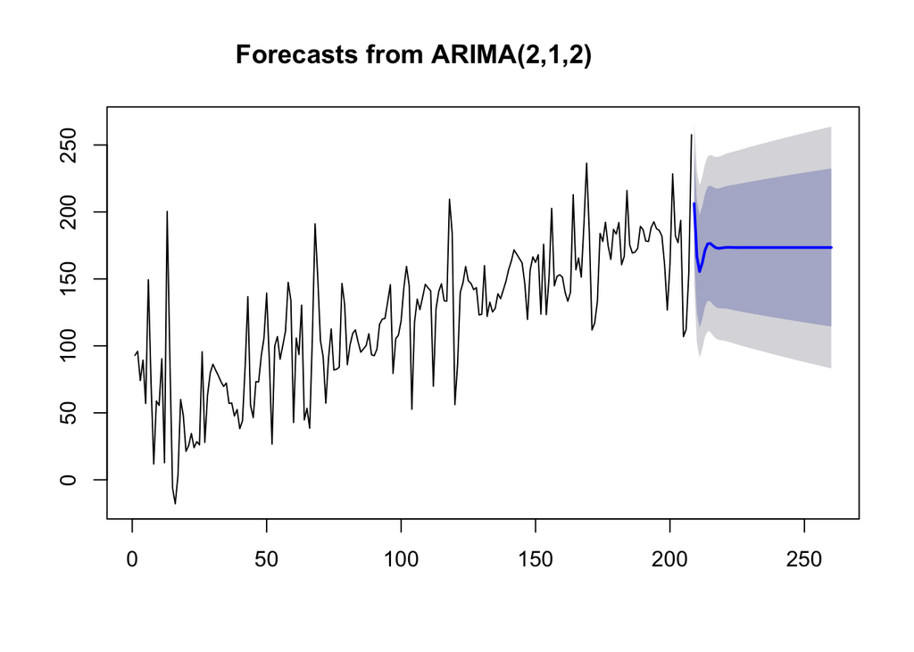

```r
# Plot
plot(forecast(object=forecast.cupcakes.sales.arima,h="52"))
```

Both time series, cupcakes sales volume and social media are of I(1) OR > 1 process, therefore the series is not stationary and has a trend and drift, and is not showing a tendency to return back to mean.

Step 1: Check if the series is stationary.

```r
sales.volume <- cupcakes_data_sales_ts$Sales.Seasonally.Adjusted
#d.sales.volume <- diff(sales.volume)
week <- cupcakes_data_sales_ts$Date


# Descriptive statistics and plotting the data
summary(sales.volume)
```

```
##    Min. 1st Qu.  Median    Mean 3rd Qu.    Max.
##  -17.86   94.85  140.00  131.50  168.10  271.70
```

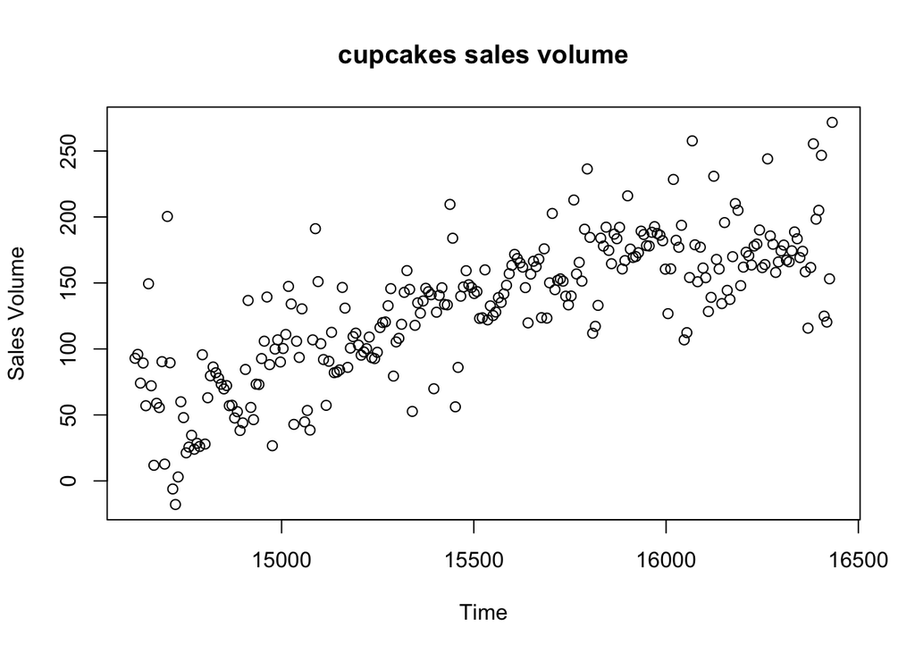

```r
#summary(d.sales.volume)

plot.ts(week, sales.volume, main = "cupcakes sales volume", xlab = "Time", ylab = "Sales Volume")
```

```r
#Based on the cupcakes sales volume time series, there appears to be a linear trend.

#Therefore, for stationarity test we include a trend element in augmented dickey fuller test.

#Augmented Dickey Fuller test for stationarity




# Sales Volume
# Null hypothesis H0: Non - Stationary

library(urca)
summary(ur.df(y=sales.volume, lags = 52, type = "trend"))
```

```
##
## ###############################################
## # Augmented Dickey-Fuller Test Unit Root Test #
## ###############################################
##
## Test regression trend
##
##
## Call:
## lm(formula = z.diff ~ z.lag.1 + 1 + tt + z.diff.lag)
##
## Residuals:
##     Min      1Q  Median      3Q     Max
## -68.552 -14.215  -0.161  12.796  60.018
##
## Coefficients:
##              Estimate Std. Error t value Pr(>|t|)
## (Intercept)  31.38449   14.72259   2.132  0.03464 *
## z.lag.1      -0.24265    0.24622  -0.985  0.32595
## tt            0.06956    0.16009   0.435  0.66453
## z.diff.lag1  -0.43699    0.26087  -1.675  0.09597 .
## z.diff.lag2  -0.83428    0.26716  -3.123  0.00215 **
## z.diff.lag3  -0.91247    0.28246  -3.230  0.00151 **
## z.diff.lag4  -0.96346    0.29570  -3.258  0.00138 **
## z.diff.lag5  -0.94724    0.31591  -2.998  0.00317 **
## z.diff.lag6  -0.98136    0.33369  -2.941  0.00378 **
## z.diff.lag7  -0.82214    0.35359  -2.325  0.02139 *
## z.diff.lag8  -0.63406    0.37243  -1.703  0.09070 .
## z.diff.lag9  -0.54901    0.38486  -1.427  0.15577
## z.diff.lag10 -0.33252    0.39017  -0.852  0.39541
## z.diff.lag11 -0.23443    0.39178  -0.598  0.55049
## z.diff.lag12 -0.14615    0.38875  -0.376  0.70747
## z.diff.lag13 -0.01856    0.38028  -0.049  0.96113
## z.diff.lag14  0.03681    0.36800   0.100  0.92044
## z.diff.lag15  0.01055    0.35179   0.030  0.97612
## z.diff.lag16  0.09781    0.33602   0.291  0.77139
## z.diff.lag17  0.02416    0.31695   0.076  0.93933
## z.diff.lag18 -0.07447    0.30238  -0.246  0.80579
## z.diff.lag19 -0.14448    0.29081  -0.497  0.62003
## z.diff.lag20 -0.09697    0.28288  -0.343  0.73222
```

[output cut: 32 more lines]

```
## ---
## Signif. codes:  0 '***' 0.001 '**' 0.01 '*' 0.05 '.' 0.1 ' ' 1
##
## Residual standard error: 26.31 on 152 degrees of freedom
## Multiple R-squared:  0.6259, Adjusted R-squared:  0.493
## F-statistic:  4.71 on 54 and 152 DF,  p-value: 2.834e-14
##
##
## Value of test-statistic is: -0.9855 1.9627 1.6686
##
## Critical values for test statistics:
##       1pct  5pct 10pct
## tau3 -3.98 -3.42 -3.13
## phi2  6.15  4.71  4.05
## phi3  8.34  6.30  5.36
```

```r
#adf.test(sales.volume, alternative = "stationary")

# KPSS test
# Null hypothesis: Series is stationary around a constant mean
# Alternative: Series is non stationary

kpss.test(sales.volume, null = "Level")
```

```
##
##  KPSS Test for Level Stationarity
##
## data:  sales.volume
## KPSS Level = 5.5938, Truncation lag parameter = 3, p-value = 0.01
```

ADF Test: The test statistics values exceed the critical values. Therefore, the series is not stationary.

:::::::::::::::::::::: SOCIAL MEDIA MENTIONS :::::::::::::::::::::::::::

```r
cupcakes_total_social_media <- cupcakes_data_social_ts$Total.Social.Media

#d.cupcakes_blogs <- diff(cupcakes_blogs)
week <- cupcakes_data_social_ts$Date


# Descriptive statistics and plotting the data
summary(cupcakes_total_social_media)
```

```
##    Min. 1st Qu.  Median    Mean 3rd Qu.    Max.
##  -98620  127600  243400  207200  277900  430500
```

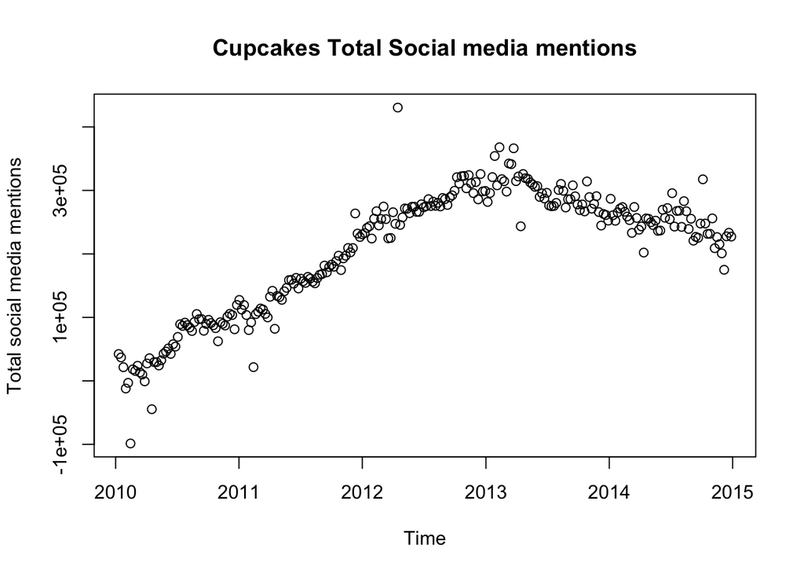

```r
plot(week, cupcakes_total_social_media, main = "Cupcakes Total Social media mentions", xlab = "Time", ylab = "Total social media mentions")
```

```r
# Augmented Dickey Fuller test for stationarity
adf.test(cupcakes_total_social_media, alternative = "stationary")
```

```
##
##  Augmented Dickey-Fuller Test
##
## data:  cupcakes_total_social_media
## Dickey-Fuller = -0.454, Lag order = 6, p-value = 0.9835
## alternative hypothesis: stationary
```

```r
# KPSS test
# Null hypothesis: Series is stationary.
# Alternative: Series is non stationary

kpss.test(cupcakes_total_social_media, null = "Level")
```

```
##
##  KPSS Test for Level Stationarity
##
## data:  cupcakes_total_social_media
## KPSS Level = 4.8255, Truncation lag parameter = 3, p-value = 0.01
```

```r
# Low p-value suggests that the series is Non - Stationary. We reject the null hypothesis of stationarity.
```

Small p-value of 0.01 for KPSS test, less than significance level of 0.05 suggests that we reject the null hypothesis that the series is stationary.

Now that we have established both series are not stationary and has a trend or drift component, and are of I(1) or > process, we perform Johansen test for cointegration.

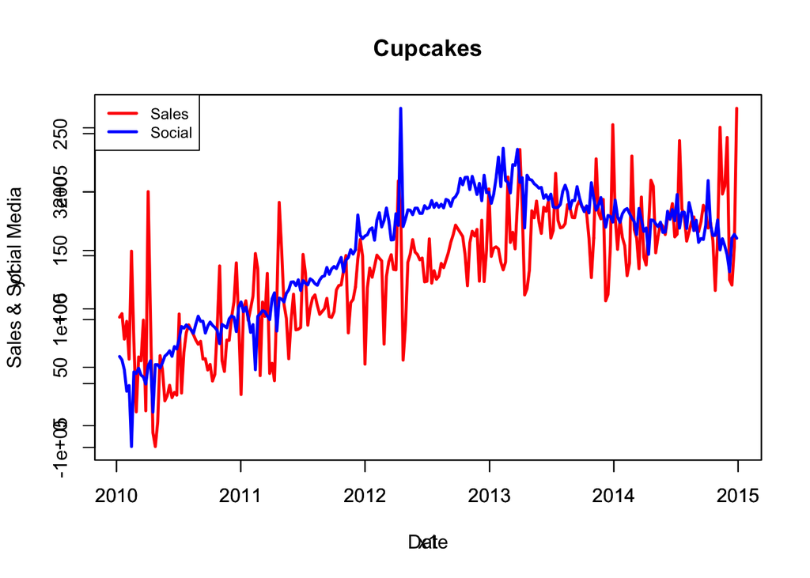

```r
# Plot Sales and Sum Social Media Mentions

x1 <- cupcakes_data_sales_ts$Date
y1 <- sales.volume
y2 <- cupcakes_total_social_media

plot( x1, y1, type="l", col="red", main = "Cupcakes", xlab = "Date", lwd = "2.5")
par(new=TRUE)
plot( x1, y2, type="l", col="blue", ylab = "Sales & Social Media", lwd = "2.5")
legend("topleft", legend=c("Sales", "Social"), col=c("red", "blue"), lwd = 2.5, cex=0.8)
```

```r
library("urca")

co.test.matrix <- cbind(sales.volume, cupcakes_total_social_media)

CoIntegrationTest =ca.jo(co.test.matrix,type="trace",K=6,ecdet="none", spec="longrun")
summary(CoIntegrationTest)
```

```
##
## ######################
## # Johansen-Procedure #
## ######################
##
## Test type: trace statistic , with linear trend
##
## Eigenvalues (lambda):
## [1] 0.09581302 0.04042481
##
## Values of teststatistic and critical values of test:
##
##           test 10pct  5pct  1pct
## r <= 1 | 10.48  6.50  8.18 11.65
## r = 0  | 36.06 15.66 17.95 23.52
##
## Eigenvectors, normalised to first column:
## (These are the cointegration relations)
##
##                                sales.volume.l6
## sales.volume.l6                   1.0000000000
## cupcakes_total_social_media.l6   -0.0004089861
##                                cupcakes_total_social_media.l6
## sales.volume.l6                                   1.000000000
## cupcakes_total_social_media.l6                    0.005773553
##
## Weights W:
## (This is the loading matrix)
##
##                               sales.volume.l6
## sales.volume.d                     -0.4832152
## cupcakes_total_social_media.d     -35.1484003
##                               cupcakes_total_social_media.l6
## sales.volume.d                                   0.001646439
## cupcakes_total_social_media.d                   -7.852846410
```

With lag of k=6, we see that our test statistic (r <= 1) of 10.48 is higher than at least one of # the critical values at 10% confidence level 6.50, we can assume there is cointegration of r time series.

# http://denizstij.blogspot.com/2013/11/cointegration-tests-adf-and-johansen.html

Running VAR model for Multivariate time series.

Multivariate time series analysis is used when one wants to model and explain the interactions and comovements among a group of time series variables

- http://faculty.washington.edu/ezivot/econ584/notes/multivariatetimeseries.pdf

Granger Causality One of the main uses of VAR models is forecasting.

The following intuitive notion of a variable’s forecasting ability is due to Granger (1969).

• If a variable, or group of variables, y1 (social media mentions) is found to be helpful for predicting another variable (sales volume), or group of variables, y2 then y1 is said to Granger-cause y2; otherwise it is said to fail to Granger-cause y2.

VAR Model Building and Evaluation steps:

1. Split Raw cupcakes sales and social data into train and validation (1 year).
2. Based on the # of observation split the ARIMA values into train and validation (1 year).
3. Run the VAR model on training set and forecast sales, social and measure the prediction accuracy by comparing the validation set.
4. Make plots of sales, social and arima (benchmark)
5. Run the model on validation set.
6. Make plots of sales, social and arima (benchmark)
7. Calculate the difference / lift / between sales arima forecasts and sales forecasts from var model.

```r
library(vars)
library(astsa)
```

```r
# Read cupcakes Google Trends data in for exogenous variable in VAR model
#setwd("/Users/kevalshah/Keval_Backup/University/UChicago/Capstone/Data/Data Clean #up/Clean data to be used for Analysis")
#cupcakes_google_trends <- read.csv("Cupcakes_Google_Trends_Searches.csv")

# Plot sales, social media and google trends

x1 <- cupcakes_data_sales_ts$Date
y1 <- cupcakes_data_sales_ts$Sales.Seasonally.Adjusted
y2 <- cupcakes_data_social_ts$Total.Social.Media
#y3 <- cupcakes_google_trends$cupcakes.Searches

#plot( x1, y1, type="l", col="red", main = "cupcakess Sales, Social #Media and Google Trends", xlab = "Date", lwd = "2.5")
#par(new=TRUE)
#plot( x1, y2, type="l", col="blue", ylab = "Social", lwd = "2.5")
#par(new=TRUE)
#plot( x1, y3, type="l", col="orange", ylab = "Social & GT", lwd = "2.5")
#legend("top", legend=c("Sales", "Social"), col=c("red", "blue"), lwd = #2.5, cex=0.8)


# Run VAR Model on Training set

length(cupcakes_data_social_ts$Total.Social.Media)
```

```
## [1] 260
```

```r
length(cupcakes_data_sales_ts$Sales.Seasonally.Adjusted)
```

```
## [1] 260
```

```r
length(cupcakes_data_sales_ts$Date)
```

```
## [1] 260
```

```r
#length(cupcakes_google_trends$cupcakes.Searches)

Train_cupcakes_sales <- cupcakes_data_sales_ts[1:208,2]
Train_cupcakes_week <- cupcakes_data_sales_ts[1:208,1]
Train_cupcakes_social <- cupcakes_data_social_ts[1:208,8]
#Train_cupcakes_google_trends <- cupcakes_google_trends[1:208,3]

# Endogenous variables
Train_VAR_cupcakes <- cbind(Train_cupcakes_sales, Train_cupcakes_social)

#VAR Select
#VARselect(Train_VAR_cupcakes, lag.max = 10, type = "both", exogen = cbind(x3 #=Train_cupcakes_google_trends))

VARselect(Train_VAR_cupcakes, lag.max = 10, type = "both")
```

```
## $selection
## AIC(n)  HQ(n)  SC(n) FPE(n)
##      7      4      2      7
##
## $criteria
##                   1            2            3            4            5
## AIC(n) 2.730897e+01 2.703831e+01 2.697300e+01 2.694539e+01 2.696205e+01
## HQ(n)  2.736275e+01 2.711898e+01 2.708055e+01 2.707983e+01 2.712338e+01
## SC(n)  2.744183e+01 2.723760e+01 2.723872e+01 2.727754e+01 2.736063e+01
## FPE(n) 7.246710e+11 5.528468e+11 5.179199e+11 5.038590e+11 5.123864e+11
##                   6            7            8            9           10
## AIC(n) 2.692218e+01 2.690933e+01 2.692329e+01 2.693598e+01 2.695998e+01
## HQ(n)  2.711040e+01 2.712444e+01 2.716529e+01 2.720486e+01 2.725575e+01
## SC(n)  2.738718e+01 2.744077e+01 2.752116e+01 2.760027e+01 2.769071e+01
## FPE(n) 4.924454e+11 4.862732e+11 4.932587e+11 4.997433e+11 5.121196e+11
```

```r
Train_VAR_model_cupcakes <- VAR(Train_VAR_cupcakes, p=7, type="both")
summary(Train_VAR_model_cupcakes)
```

```
##
## VAR Estimation Results:
## =========================
## Endogenous variables: Train_cupcakes_sales, Train_cupcakes_social
## Deterministic variables: both
## Sample size: 201
## Log Likelihood: -3240.266
## Roots of the characteristic polynomial:
## 0.9997 0.8379 0.8379 0.8149 0.8149 0.8033 0.8033 0.7977 0.7727 0.7727 0.7495 0.7495 0.723 0.003
## Call:
## VAR(y = Train_VAR_cupcakes, p = 7, type = "both")
##
##
## Estimation results for equation Train_cupcakes_sales:
## =====================================================
## Train_cupcakes_sales = Train_cupcakes_sales.l1 + Train_cupcakes_social.l1 + Train_cupcakes_sales.l2 + Train_cupcakes_social.l2 + Train_cupcakes_sales.l3 + Train_cupcakes_social.l3 + Train_cupcakes_sales.l4 + Train_cupcakes_social.l4 + Train_cupcakes_sales.l5 + Train_cupcakes_social.l5 + Train_cup…
##
##                            Estimate Std. Error t value Pr(>|t|)
## Train_cupcakes_sales.l1   3.231e-01  7.251e-02   4.456 1.44e-05 ***
## Train_cupcakes_social.l1 -8.352e-05  9.269e-05  -0.901 0.368749
## Train_cupcakes_sales.l2  -2.559e-01  7.362e-02  -3.475 0.000635 ***
## Train_cupcakes_social.l2  2.406e-04  8.789e-05   2.738 0.006785 **
## Train_cupcakes_sales.l3  -1.076e-01  7.722e-02  -1.393 0.165183
## Train_cupcakes_social.l3 -2.220e-04  9.112e-05  -2.436 0.015787 *
## Train_cupcakes_sales.l4   1.674e-02  7.836e-02   0.214 0.831087
## Train_cupcakes_social.l4  8.206e-05  9.263e-05   0.886 0.376824
## Train_cupcakes_sales.l5   3.801e-02  7.686e-02   0.495 0.621534
## Train_cupcakes_social.l5  7.810e-05  9.256e-05   0.844 0.399897
## Train_cupcakes_sales.l6  -1.121e-01  7.392e-02  -1.517 0.131088
## Train_cupcakes_social.l6  1.232e-04  8.968e-05   1.373 0.171279
## Train_cupcakes_sales.l7   1.905e-01  7.045e-02   2.704 0.007489 **
## Train_cupcakes_social.l7 -1.190e-04  8.937e-05  -1.332 0.184564
## const                     3.973e+01  9.108e+00   4.362 2.14e-05 ***
## trend                     4.762e-01  1.513e-01   3.146 0.001928 **
## ---
## Signif. codes:  0 '***' 0.001 '**' 0.01 '*' 0.05 '.' 0.1 ' ' 1
##
##
## Residual standard error: 28.41 on 185 degrees of freedom
## Multiple R-Squared: 0.7215,  Adjusted R-squared: 0.6989
```

[output cut: 28 more lines]

```
## Residual standard error: 22450 on 185 degrees of freedom
## Multiple R-Squared: 0.9532,  Adjusted R-squared: 0.9494
## F-statistic: 251.4 on 15 and 185 DF,  p-value: < 2.2e-16
##
##
##
## Covariance matrix of residuals:
##                       Train_cupcakes_sales Train_cupcakes_social
## Train_cupcakes_sales                 807.2                 12152
## Train_cupcakes_social              12152.3             504137565
##
## Correlation matrix of residuals:
##                       Train_cupcakes_sales Train_cupcakes_social
## Train_cupcakes_sales               1.00000               0.01905
## Train_cupcakes_social              0.01905               1.00000
```

The adjusted R-Squared of 69% for equation predicting sales as dependent variable and endogenous variables of social media and sales with lag order of 7 and with constant and trend deterministic variable indicates a good fit.

On the other hand, the inverse, of predicting social media with sales as predictors has Adj. R-Squared of 94% which indicates that sales is a good lagging indicator of social media.

Now, we fit our training model on our validation set and check the prediction error / accuracy.

```r
# Run VAR Model on Validation / Test Set

Test_cupcakes_sales <- cupcakes_data_sales_ts[209:260,2]
Test_cupcakes_week <- cupcakes_data_sales_ts[209:260,1]
Test_cupcakes_social <- cupcakes_data_social_ts[209:260,8]
#Test_cupcakes_google_trends <- cupcakes_google_trends[209:260,3]

length(Test_cupcakes_sales)
```

```
## [1] 52
```

```r
length(Test_cupcakes_week)
```

```
## [1] 52
```

```r
length(Test_cupcakes_social)
```

```
## [1] 52
```

```r
#length(Test_cupcakes_google_trends)

# Endogenous variables
Test_VAR_cupcakes <- cbind(Test_cupcakes_sales, Test_cupcakes_social)
```

```r
# cupcakes prediction

#var_train_forecasts <- predict(Train_VAR_model_cupcakes, n.ahead = 52, ci = 0.95, dumvar = #cbind(x3 =Test_cupcakes_google_trends))

var_train_forecasts <- predict(Train_VAR_model_cupcakes, n.ahead = 52, ci = 0.95)



summary(var_train_forecasts)
```

```
##          Length Class  Mode
## fcst       2    -none- list
## endog    416    -none- numeric
## model     10    varest list
## exo.fcst   0    -none- NULL
```

```r
head(var_train_forecasts)
```

```
## $fcst
## $fcst$Train_cupcakes_sales
##           fcst    lower    upper       CI
##  [1,] 221.9178 166.2320 277.6036 55.68581
##  [2,] 166.6991 108.0846 225.3136 58.61449
##  [3,] 167.5273 107.6828 227.3718 59.84452
##  [4,] 171.6834 110.5094 232.8575 61.17405
##  [5,] 179.0979 117.6853 240.5106 61.41264
##  [6,] 175.5768 113.6656 237.4880 61.91121
##  [7,] 191.8087 129.3309 254.2865 62.47777
##  [8,] 198.3002 135.5359 261.0646 62.76432
##  [9,] 186.8872 123.8706 249.9037 63.01652
## [10,] 181.5634 118.5449 244.5818 63.01844
## [11,] 179.9631 116.8613 243.0650 63.10182
## [12,] 186.1872 122.9269 249.4474 63.26021
```

[output cut: 354 more lines]

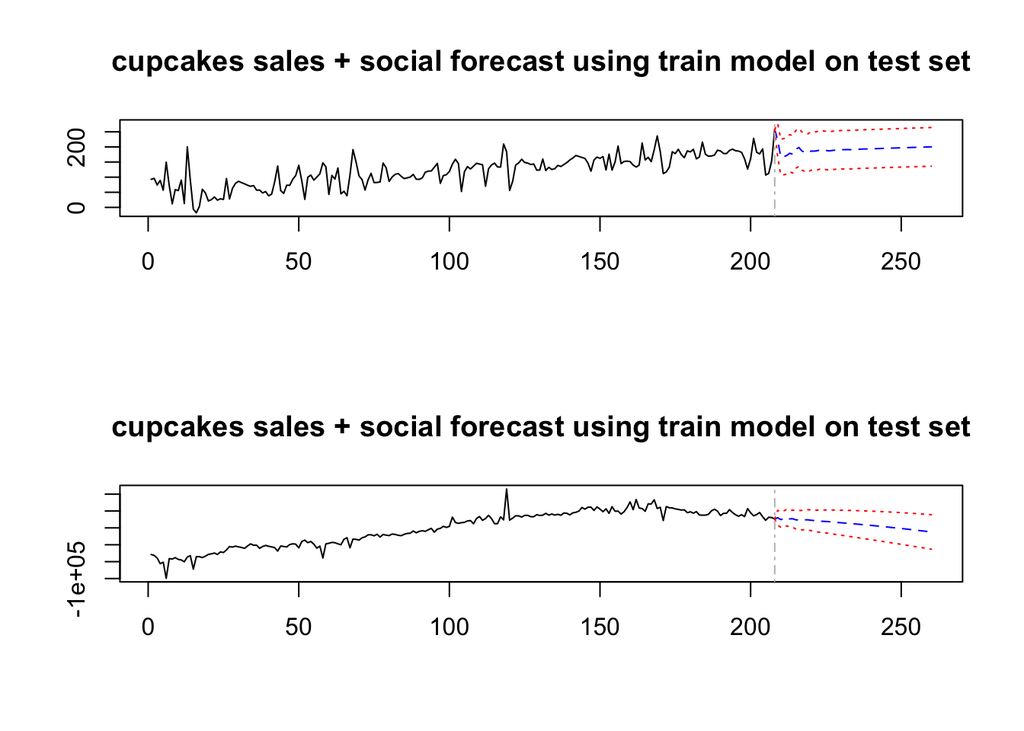

```r
plot(var_train_forecasts, type = "l", main = "cupcakes sales + social forecast using train model on test set")
```

```r
# Check accuracy of our forecasts using train model on test data

# cupcakes sales volume forecast
accuracy(var_train_forecasts$fcst$Train_cupcakes_sales[,1], Test_cupcakes_sales)
```

```
##                 ME     RMSE      MAE       MPE     MAPE
## Test set -17.37229 35.65068 29.79953 -13.31054 18.48432
```

```r
# cupcakes social media forecast
accuracy(var_train_forecasts$fcst$Train_cupcakes_social[,1], Test_cupcakes_social)
```

```
##                ME    RMSE      MAE      MPE     MAPE
## Test set 26985.46 36730.7 29487.94 10.45574 11.66127
```

Plot Raw Sales and Social media with Forecasts

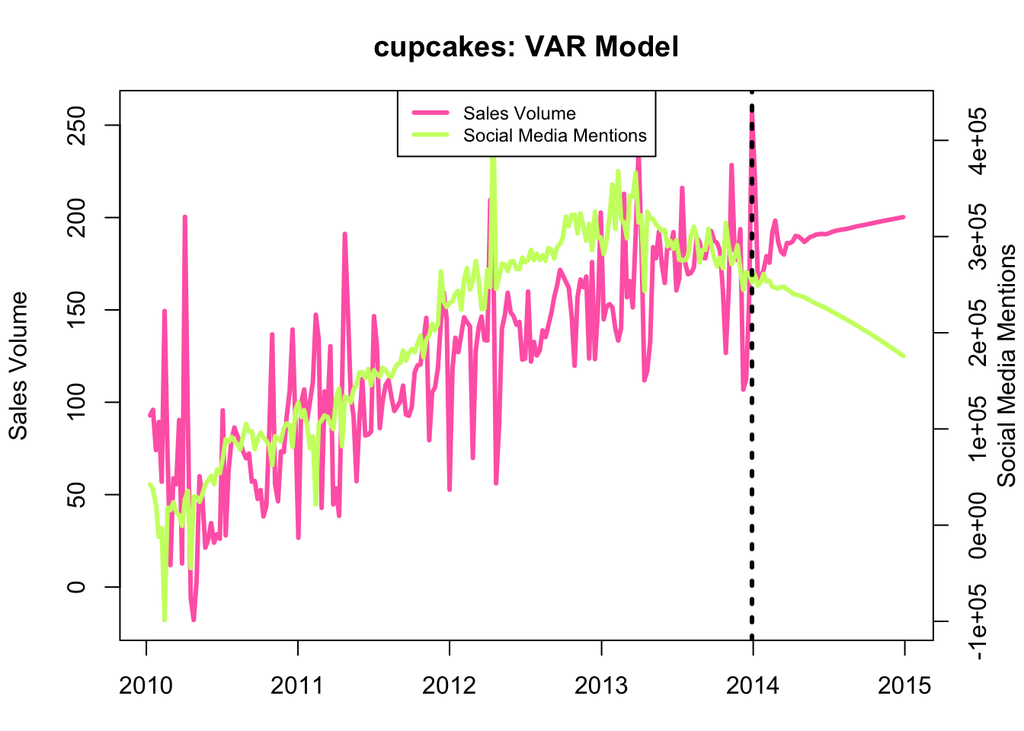

```r
# Append raw + forecast
cupcakes.sales.VAR.All <- append(Train_cupcakes_sales, var_train_forecasts$fcst$Train_cupcakes_sales[,1])
cupcakes.social.VAR.All <- append(Train_cupcakes_social, var_train_forecasts$fcst$Train_cupcakes_social[,1])
cupcakes.week.All <- append(Train_cupcakes_week, Test_cupcakes_week)

cupcakes_df_total <- data.frame(cupcakes.week.All, cupcakes.sales.VAR.All, cupcakes.social.VAR.All)


mar.default <- c(3,3,3,3) + 0.1
par(mar = mar.default + c(0, 1, 0, 0))
plot(cupcakes_df_total[,1:2], type="l",
     ylab="Sales Volume", xlab="Time (Year)",
     lwd=3, main="cupcakes: VAR Model", col="hotpink")
par(new=TRUE)
plot(cupcakes_df_total[,3], type="l", col="darkolivegreen1", axes=FALSE,
     ylab="", xlab="", lwd=3)
axis(4)
mtext("Social Media Mentions", side=4, line=+2, adj=0.5)
abline(v=208, lty=3, lwd=3)
legend("top", legend=c("Sales Volume", "Social Media Mentions"),
       col=c("hotpink","darkolivegreen1"), lwd=3, cex=0.75)
```

Comparing sales prediction to ARIMA benchmark, make plots and calculate lift

```r
# Calculate accuracy of arima sales forecast and VAR model sales forecast to actual sales values in
# test set
# Compare prediction error of each and calculate the lift obtained from prediction error.


# Difference in Predictions cupcakess

All_cupcakes_Forecasts <- cbind.data.frame(Test_week = as.Date(Test_cupcakes_week), AR=forecast.cupcakes.sales.arima$mean, VAR=var_train_forecasts$fcst$Train_cupcakes_sales[,1],
                   ACTUAL=Test_cupcakes_sales)
head(All_cupcakes_Forecasts)
```

```
##    Test_week       AR      VAR   ACTUAL
## 1 2014-01-05 206.2756 221.9178 178.9041
## 2 2014-01-12 166.8020 166.6991 150.9161
## 3 2014-01-19 155.5121 167.5273 177.1060
## 4 2014-01-26 161.8652 171.6834 161.3344
## 5 2014-02-02 171.2481 179.0979 153.9906
## 6 2014-02-09 176.1993 175.5768 128.3848
```

```r
# Calculate the RMSE. Predicted - Actual values - ARIMA.
AR.error <- forecast.cupcakes.sales.arima$mean - Test_cupcakes_sales
ar.cupcakes.sales.rmse <- sqrt(mean(AR.error^2))
# Calculate MAE
ar.cupcakes.sales.mae <- mean(abs(AR.error))


# Calculate the RMSE. Predicted - Actual values - VAR.
VAR.error <- var_train_forecasts$fcst$Train_cupcakes_sales[,1] - Test_cupcakes_sales
var.cupcakes.sales.rmse <- sqrt(mean(VAR.error^2))
# Calculate MAE
var.cupcakes.sales.mae <- mean(abs(VAR.error))


# Calculate Lift in prediction accuracy
paste(round((((ar.cupcakes.sales.rmse - var.cupcakes.sales.rmse)/ar.cupcakes.sales.rmse))*100, digits = 2), "%", sep = "")
```

```
## [1] "-9.33%"
```

```r
paste(round((((ar.cupcakes.sales.mae - var.cupcakes.sales.mae)/ar.cupcakes.sales.mae))*100, digits = 2), "%", sep = "")
```

```
## [1] "-27.34%"
```

```r
# Create a table to compare RMSE and MAE
accuracy_table <- matrix(c(32.60731,35.65068,"-9.33%",23.40172,29.79953,"-27.34%"),ncol=3,byrow=TRUE)
colnames(accuracy_table) <- c("ARIMA","VAR", "Lift in Prediction accuracy")
rownames(accuracy_table) <- c("RMSE","MAE")
accuracy_table
```

```
##      ARIMA      VAR        Lift in Prediction accuracy
## RMSE "32.60731" "35.65068" "-9.33%"
## MAE  "23.40172" "29.79953" "-27.34%"
```

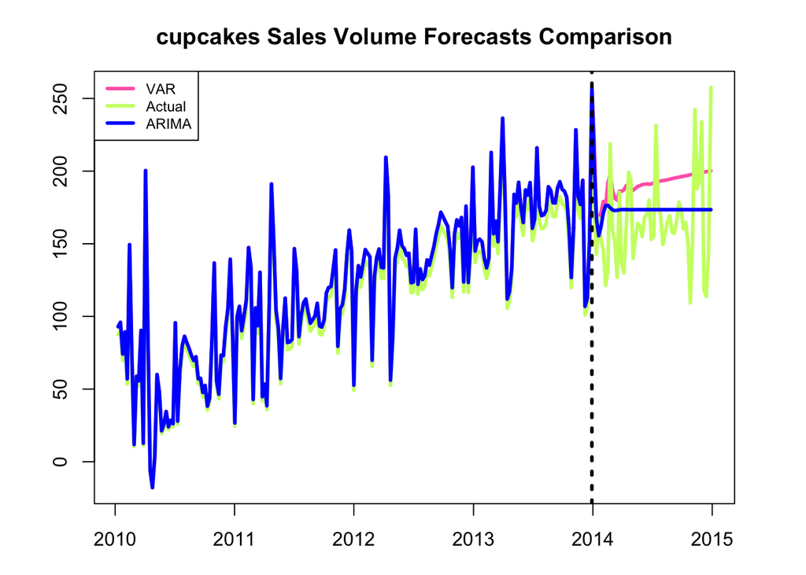

```r
# Append ARIMA sales data and forecasts
cupcakes.sales.arima.All <- append(cupcakes_train_sales_data_arima, forecast.cupcakes.sales.arima$mean)

cupcakes.sales.actual.All <- append(Train_cupcakes_sales, Test_cupcakes_sales)

# Create a dataframe w Raw sales data, VAR Forecasts, ARIMA Forecasts and
# Test data.

cupcakes_df_total_final <- cbind.data.frame(cupcakes.week.All, cupcakes.sales.VAR.All, cupcakes.sales.actual.All, cupcakes.sales.arima.All)


mar.default <- c(3,3,3,3) + 0.1
par(mar = mar.default + c(0, 1, 0, 0))
plot(cupcakes_df_total_final[,1:2], type="l",
     ylab="", xlab="Time (Year)",
     lwd=3, main="cupcakes Sales Volume Forecasts Comparison", col="hotpink")
par(new=TRUE)
# Actual data train + test
plot(cupcakes_df_total_final[,3], type="l", col="darkolivegreen1", axes=FALSE,
     ylab="", xlab="", lwd=3)
par(new=TRUE)
# ARIMA Forecast
plot(cupcakes_df_total_final[,4], type="l", col="blue", axes=FALSE,
     ylab="", xlab="", lwd=3)

abline(v=208, lty=3, lwd=3)
legend("topleft", legend=c("VAR", "Actual", "ARIMA"),
       col=c("hotpink","darkolivegreen1","blue"), lwd=3, cex=0.75)
```

Based on the above plot we can see that ARIMA model predicts better than VAR model. This is in contrast to clementine where VAR model indeed had better accuracy rates.

```r
print(accuracy_table)
```

```
##      ARIMA      VAR        Lift in Prediction accuracy
## RMSE "32.60731" "35.65068" "-9.33%"
## MAE  "23.40172" "29.79953" "-27.34%"
```

Predictions for 2015

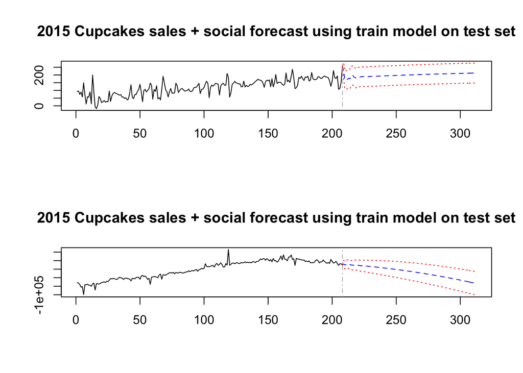

```r
var_cupcakes_forecasts_2015 <- predict(Train_VAR_model_cupcakes, n.ahead = 104, ci = 0.95)

plot(var_cupcakes_forecasts_2015, type = "l", main = "2015 Cupcakes sales + social forecast using train model on test set")
```